# R_Project

Amy Pollpeter

10/9/2019

# R Project for BCB 546 - Amy Pollpeter

## Prepare the Envionment

### Install the needed packages for the project.

```r
library(tidyverse)
library(reshape2)
```

### Download and import the original data files.

```r
download.file("https://raw.githubusercontent.com/EEOB-BioData/BCB546X-Fall2019/master/assignments/UNIX_Assignment/snp_position.txt", destfile = "./snp_position.txt")

download.file("https://raw.githubusercontent.com/EEOB-BioData/BCB546X-Fall2019/master/assignments/UNIX_Assignment/fang_et_al_genotypes.txt", destfile = "./fang_et_al_genotypes.txt")

fang_data <- read_tsv("./fang_et_al_genotypes.txt")
snp_data <- read_tsv("./snp_position.txt")
```

## Inspect the data files

fang data has 986 columns and 2782 rows. snp_data has 15 columns and 983 rows.

```r
ncol(fang_data)
```

```
## [1] 986
```

```r
nrow(fang_data)
```

```
## [1] 2782
```

```r
ncol(snp_data)
```

```
## [1] 15
```

```r
nrow(snp_data)
```

```
## [1] 983
```

```r
file.info("fang_et_al_genotypes.txt")
```

```
##                              size isdir mode               mtime
## fang_et_al_genotypes.txt 11054722 FALSE  666 2019-10-23 09:39:23
##                                        ctime               atime exe
## fang_et_al_genotypes.txt 2019-10-09 21:17:36 2019-10-23 09:39:23  no
```

```r
file.info("snp_data.txt")
```

```
##              size isdir mode mtime ctime atime  exe
## snp_data.txt   NA    NA <NA>  <NA>  <NA>  <NA> <NA>
```

## Separating Maize and Teosinte Data

I used the filter command to separate the teosinte and maize data into separate data frames. I then used the write commmand to save these new data frames as new text files.

```r
teosinte_data <- filter(fang_data, `Group` %in% c("ZMPBA", "ZMPIL", "ZMPJA"))
maize_data <- filter(fang_data, `Group` %in% c("ZMMIL", "ZMMLR", "ZMMMR"))
write_tsv(maize_data, "maize_data.txt")
write_tsv(teosinte_data, "teosinte_data.txt")
```

## Transposing Maize and Teosinte Data

I used the transpose (t) function to transform both the maize and teosinte data to switch the row and column information.

```r
transposed_maize <- t(maize_data)
transposed_teosinte <- t(teosinte_data)
transposed_maize_df <- as.data.frame(transposed_maize)
transposed_teosinte_df <- as.data.frame(transposed_teosinte)
write_tsv(transposed_maize_df, "transposed_maize_data.txt", na = "NA", append = FALSE, col_names = FALSE)
write_tsv(transposed_teosinte_df, "transposed_teosinte_data.txt", na = "NA", append = FALSE, col_names = FALSE)
```

## Preparing SNP file to be joined with maize and teosinte files

First I read the snp_position file into R. Then I selected the 3 columns I wanted to use when joining the files. Finally I removed the header.

```r
snp_position <- read_tsv("D:/Documents/BCB546/Cloned_Repository/BCB546X-Fall2019/assignments/UNIX_Assignment/snp_position.txt")
snp_position_edit <- select(snp_position, SNP_ID, Chromosome, Position)
snp_position_noheader <- unname(snp_position_edit)
snp_position_sorted <- arrange(snp_position_edit, SNP_ID)
```

## Preparing Maize and Teosinte Files to be joined to SNP data

Ran the first command -c(1) three times to remove the first three lines of each file. While the resulting files are technically intermediate files, I still used the write command to save them.

```r
transposed_maize_edit <- transposed_maize_df[-c(1),]
transposed_maize_edit <- transposed_maize_edit[-c(1),]
transposed_maize_edit <- transposed_maize_edit[-c(1),]
transposed_teosinte_edit <- transposed_teosinte_df[-c(1),]
transposed_teosinte_edit <- transposed_teosinte_edit[-c(1),]
transposed_teosinte_edit <- transposed_teosinte_edit[-c(1),]
write_tsv(transposed_teosinte_edit, "transposed_teosinte_data_edit.txt", na = "NA", append = FALSE, col_names = FALSE)
write_tsv(transposed_maize_df, "transposed_maize_data.txt", na = "NA", append = FALSE, col_names = FALSE)
```

## Joining the files

After joining the files using cbind, the row name was redundant with the first column so I used the NULL command to remove the rownames from the files before writing them.

```r
maize_joined <- cbind(snp_position_sorted, transposed_maize_edit)
teosinte_joined <- cbind(snp_position_sorted, transposed_teosinte_edit)
rownames(maize_joined) <- NULL
rownames(teosinte_joined) <- NULL
write_tsv(maize_joined, "maize_joined.txt", na = "NA", append = FALSE, col_names = TRUE)
write_tsv(teosinte_joined, "teosinte_joined.txt", na = "NA", append = FALSE, col_names = TRUE)
rownames(maize_joined) <- NULL
rownames(teosinte_joined) <- NULL
```

## Replacing missing data

Since we want one copy of the files to have missing data indicated by ? (as it currently is) and a second copy of the files indicating missing data with “-”, I replaced the ? and made a new file before separating by chromosome number. Using the lapply function also reassigns the new file as a list so I then switched it back to a data frame using the as.data.frame command.

```r
maize_joined_alt <- lapply(maize_joined, gsub, pattern = "?", replacement = "-", fixed = TRUE)
maize_joined_alt <- as.data.frame(maize_joined_alt)
teosinte_joined_alt <- lapply(teosinte_joined, gsub, pattern = "?", replacement = "-", fixed = TRUE)
teosinte_joined_alt <- as.data.frame(teosinte_joined_alt)
write_tsv(maize_joined_alt, "maize_joined_alt.txt", na = "NA", append = FALSE, col_names = TRUE)
write_tsv(teosinte_joined_alt, "teosinte_joined_alt.txt", na = "NA", append = FALSE, col_names = TRUE)
```

## Sorting files by chromosome #.

```r
maize_unknownChr <- filter(maize_joined, Chromosome == "unknown")
maize_multipleChr <- filter(maize_joined, Chromosome == "multiple")
maize_joined <- transform(maize_joined, Chromosome = as.numeric(Chromosome), Position = as.numeric(Position))
maize_joined_alt <- transform(maize_joined_alt, Chromosome = as.numeric(Chromosome), Position = as.numeric (Position))
maize_joined_sorted <- arrange(maize_joined, Chromosome, Position)
maize_joined_alt_sorted <- arrange(maize_joined_alt, Chromosome, desc(Position))
maize_Chr1 <- filter(maize_joined_sorted, Chromosome == 1)
maize_Chr2 <- filter(maize_joined_sorted, Chromosome == 2)
maize_Chr3 <- filter(maize_joined_sorted, Chromosome == 3)
maize_Chr4 <- filter(maize_joined_sorted, Chromosome == 4)
maize_Chr5 <- filter(maize_joined_sorted, Chromosome == 5)
maize_Chr6 <- filter(maize_joined_sorted, Chromosome == 6)
maize_Chr7 <- filter(maize_joined_sorted, Chromosome == 7)
maize_Chr8 <- filter(maize_joined_sorted, Chromosome == 8)
maize_Chr9 <- filter(maize_joined_sorted, Chromosome == 9)
maize_Chr10 <- filter(maize_joined_sorted, Chromosome == 10)
maize_Chr1_desc <- filter(maize_joined_alt_sorted, Chromosome == 1)
maize_Chr2_desc <- filter(maize_joined_alt_sorted, Chromosome == 2)
maize_Chr3_desc <- filter(maize_joined_alt_sorted, Chromosome == 3)
maize_Chr4_desc <- filter(maize_joined_alt_sorted, Chromosome == 4)
maize_Chr5_desc <- filter(maize_joined_alt_sorted, Chromosome == 5)
maize_Chr6_desc <- filter(maize_joined_alt_sorted, Chromosome == 6)
maize_Chr7_desc <- filter(maize_joined_alt_sorted, Chromosome == 7)
maize_Chr8_desc <- filter(maize_joined_alt_sorted, Chromosome == 8)
maize_Chr9_desc <- filter(maize_joined_alt_sorted, Chromosome == 9)
maize_Chr10_desc <- filter(maize_joined_alt_sorted, Chromosome == 10)
teosinte_unknownChr <- filter(teosinte_joined, Chromosome == "unknown")
teosinte_multipleChr <- filter(teosinte_joined, Chromosome == "multiple")
teosinte_joined <- transform(teosinte_joined, Chromosome = as.numeric(Chromosome), Position = as.numeric (Position))
teosinte_joined_alt <- transform(teosinte_joined_alt, Chromosome = as.numeric(Chromosome), Position = as.numeric (Position))
teosinte_joined_sorted <- arrange(teosinte_joined, Chromosome, Position)
teosinte_joined_alt_sorted <- arrange(teosinte_joined_alt, Chromosome, desc(Position))
teosinte_Chr1 <- filter(teosinte_joined_sorted, Chromosome == 1)
teosinte_Chr2 <- filter(teosinte_joined_sorted, Chromosome == 2)
teosinte_Chr3 <- filter(teosinte_joined_sorted, Chromosome == 3)
teosinte_Chr4 <- filter(teosinte_joined_sorted, Chromosome == 4)
teosinte_Chr5 <- filter(teosinte_joined_sorted, Chromosome == 5)
teosinte_Chr6 <- filter(teosinte_joined_sorted, Chromosome == 6)
teosinte_Chr7 <- filter(teosinte_joined_sorted, Chromosome == 7)
teosinte_Chr8 <- filter(teosinte_joined_sorted, Chromosome == 8)
teosinte_Chr9 <- filter(teosinte_joined_sorted, Chromosome == 9)
teosinte_Chr10 <- filter(teosinte_joined_sorted, Chromosome == 10)
teosinte_Chr1_desc <- filter(teosinte_joined_alt_sorted, Chromosome == 1)
teosinte_Chr2_desc <- filter(teosinte_joined_alt_sorted, Chromosome == 2)
teosinte_Chr3_desc <- filter(teosinte_joined_alt_sorted, Chromosome == 3)
teosinte_Chr4_desc <- filter(teosinte_joined_alt_sorted, Chromosome == 4)
teosinte_Chr5_desc <- filter(teosinte_joined_alt_sorted, Chromosome == 5)
teosinte_Chr6_desc <- filter(teosinte_joined_alt_sorted, Chromosome == 6)
teosinte_Chr7_desc <- filter(teosinte_joined_alt_sorted, Chromosome == 7)
teosinte_Chr8_desc <- filter(teosinte_joined_alt_sorted, Chromosome == 8)
teosinte_Chr9_desc <- filter(teosinte_joined_alt_sorted, Chromosome == 9)
teosinte_Chr10_desc <- filter(teosinte_joined_alt_sorted, Chromosome == 10)
```

Next, I will need to write these output data frames to actual files to be added to the git repository.

```r
write_tsv(maize_unknownChr, "maize_unknownChr.txt", na = "NA", append = FALSE, col_names = TRUE)
write_tsv(maize_multipleChr, "maize_multipleChr.txt", na = "NA", append = FALSE, col_names = TRUE)
write_tsv(maize_Chr1, "maize_Chr1.txt", na = "NA", append = FALSE, col_names = TRUE)
write_tsv(maize_Chr2, "maize_Chr2.txt", na = "NA", append = FALSE, col_names = TRUE)
write_tsv(maize_Chr3, "maize_Chr3.txt", na = "NA", append = FALSE, col_names = TRUE)
write_tsv(maize_Chr4, "maize_Chr4.txt", na = "NA", append = FALSE, col_names = TRUE)
write_tsv(maize_Chr5, "maize_Chr5.txt", na = "NA", append = FALSE, col_names = TRUE)
write_tsv(maize_Chr6, "maize_Chr6.txt", na = "NA", append = FALSE, col_names = TRUE)
write_tsv(maize_Chr7, "maize_Chr7.txt", na = "NA", append = FALSE, col_names = TRUE)
write_tsv(maize_Chr8, "maize_Chr8.txt", na = "NA", append = FALSE, col_names = TRUE)
write_tsv(maize_Chr9, "maize_Chr9.txt", na = "NA", append = FALSE, col_names = TRUE)
write_tsv(maize_Chr10, "maize_Ch10.txt", na = "NA", append = FALSE, col_names = TRUE)
write_tsv(maize_Chr1_desc, "maize_Chr1_desc.txt", na = "NA", append = FALSE, col_names = TRUE)
write_tsv(maize_Chr2_desc, "maize_Chr2_desc.txt", na = "NA", append = FALSE, col_names = TRUE)
write_tsv(maize_Chr3_desc, "maize_Chr3_desc.txt", na = "NA", append = FALSE, col_names = TRUE)
write_tsv(maize_Chr4_desc, "maize_Chr4_desc.txt", na = "NA", append = FALSE, col_names = TRUE)
write_tsv(maize_Chr5_desc, "maize_Chr5_desc.txt", na = "NA", append = FALSE, col_names = TRUE)
write_tsv(maize_Chr6_desc, "maize_Chr6_desc.txt", na = "NA", append = FALSE, col_names = TRUE)
write_tsv(maize_Chr7_desc, "maize_Chr7_desc.txt", na = "NA", append = FALSE, col_names = TRUE)
write_tsv(maize_Chr8_desc, "maize_Chr8_desc.txt", na = "NA", append = FALSE, col_names = TRUE)
write_tsv(maize_Chr9_desc, "maize_Chr9_desc.txt", na = "NA", append = FALSE, col_names = TRUE)
write_tsv(maize_Chr10_desc, "maize_Chr10_desc.txt", na = "NA", append = FALSE, col_names = TRUE)
write_tsv(teosinte_Chr1, "teosinte_Chr1.txt", na = "NA", append = FALSE, col_names = TRUE)
write_tsv(teosinte_Chr2, "teosinte_Chr2.txt", na = "NA", append = FALSE, col_names = TRUE)
write_tsv(teosinte_Chr3, "teosinte_Chr3.txt", na = "NA", append = FALSE, col_names = TRUE)
write_tsv(teosinte_Chr4, "teosinte_Chr4.txt", na = "NA", append = FALSE, col_names = TRUE)
write_tsv(teosinte_Chr5, "teosinte_Chr5.txt", na = "NA", append = FALSE, col_names = TRUE)
write_tsv(teosinte_Chr6, "teosinte_Chr6.txt", na = "NA", append = FALSE, col_names = TRUE)
write_tsv(teosinte_Chr7, "teosinte_Chr7.txt", na = "NA", append = FALSE, col_names = TRUE)
write_tsv(teosinte_Chr8, "teosinte_Chr8.txt", na = "NA", append = FALSE, col_names = TRUE)
write_tsv(teosinte_Chr9, "teosinte_Chr9.txt", na = "NA", append = FALSE, col_names = TRUE)
write_tsv(teosinte_Chr10, "teosinte_Ch10.txt", na = "NA", append = FALSE, col_names = TRUE)
write_tsv(teosinte_Chr1_desc, "teosinte_Chr1_desc.txt", na = "NA", append = FALSE, col_names = TRUE)
write_tsv(teosinte_Chr2_desc, "teosinte_Chr2_desc.txt", na = "NA", append = FALSE, col_names = TRUE)
write_tsv(teosinte_Chr3_desc, "teosinte_Chr3_desc.txt", na = "NA", append = FALSE, col_names = TRUE)
write_tsv(teosinte_Chr4_desc, "teosinte_Chr4_desc.txt", na = "NA", append = FALSE, col_names = TRUE)
write_tsv(teosinte_Chr5_desc, "teosinte_Chr5_desc.txt", na = "NA", append = FALSE, col_names = TRUE)
write_tsv(teosinte_Chr6_desc, "teosinte_Chr6_desc.txt", na = "NA", append = FALSE, col_names = TRUE)
write_tsv(teosinte_Chr7_desc, "teosinte_Chr7_desc.txt", na = "NA", append = FALSE, col_names = TRUE)
write_tsv(teosinte_Chr8_desc, "teosinte_Chr8_desc.txt", na = "NA", append = FALSE, col_names = TRUE)
write_tsv(teosinte_Chr9_desc, "teosinte_Chr9_desc.txt", na = "NA", append = FALSE, col_names = TRUE)
write_tsv(teosinte_Chr10_desc, "teosinte_Chr10_desc.txt", na = "NA", append = FALSE, col_names = TRUE)
write_tsv(teosinte_unknownChr, "teosinte_unknownChr.txt", na = "NA", append = FALSE, col_names = TRUE)
write_tsv(teosinte_multipleChr, "teosinte_multipleChr.txt", na = "NA", append = FALSE, col_names = TRUE)
```

## Plotting Data.

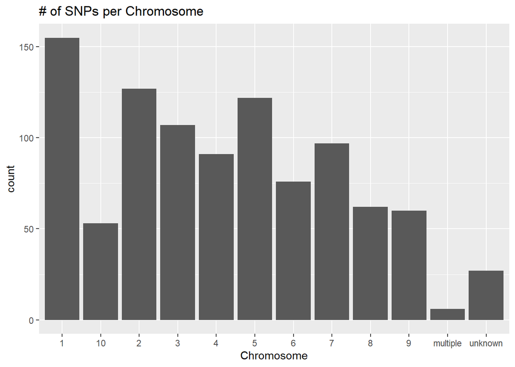

```r
SNP_graph <- ggplot(data = snp_position_edit) + geom_bar(mapping = aes(x=Chromosome))
SNP_graph + ggtitle("# of SNPs per Chromosome")
```

## Density Plot

```r
snp_position_edit1 <- transform(snp_position_edit, Chromosome = as.integer(Chromosome), Position = as.numeric(Position))
```

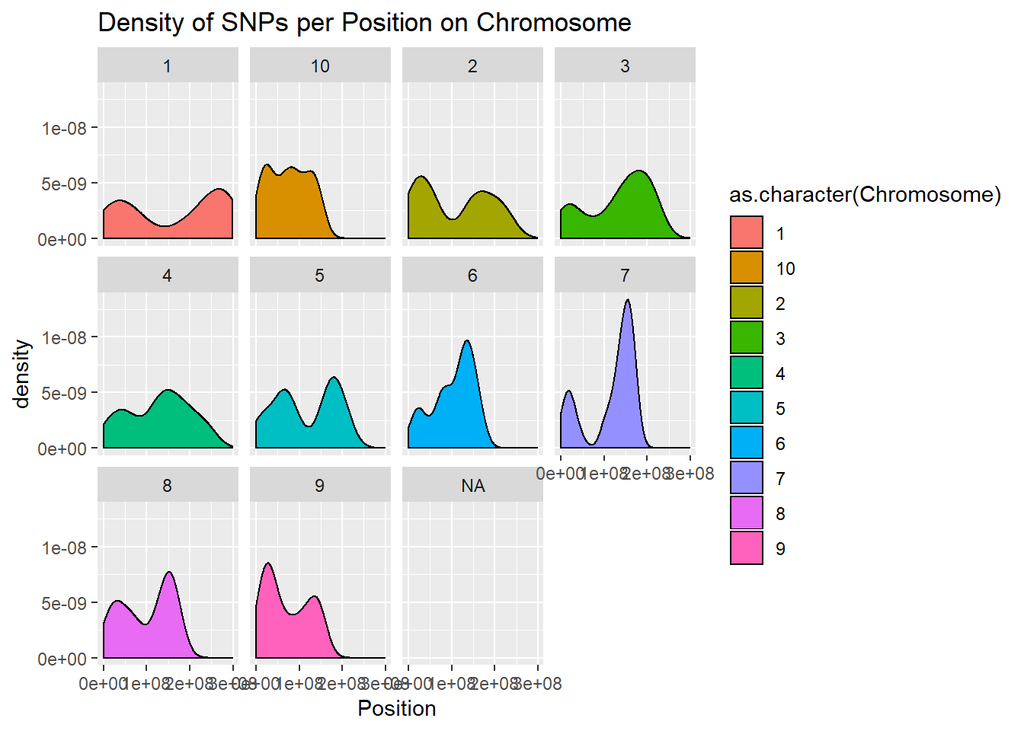

```r
density <- ggplot(snp_position_edit1, aes(x=Position, na.rm =TRUE)) + geom_density(aes(fill = as.character(Chromosome))) + facet_wrap(~as.character(Chromosome))
density + ggtitle("Density of SNPs per Position on Chromosome")
```

## Amount of Heterozygosity

I plotted in this in two different ways, the first is over the entire fang dataset. The second splits it up by species as either Maize, Teosinte, or Other.

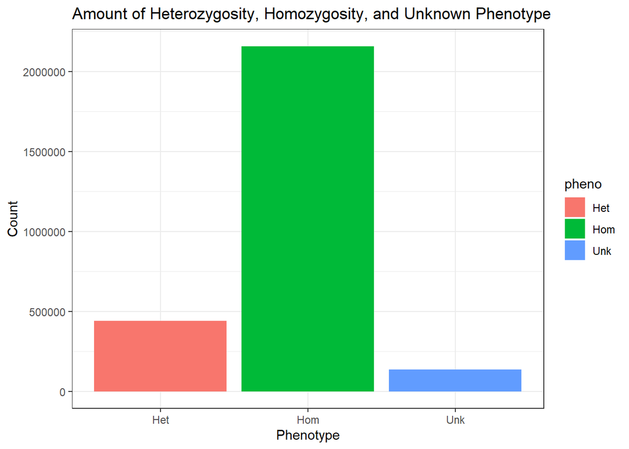

```r
fang_melt <- melt(data = fang_data, id.var = "Group", measure.var = names(fang_data[4:986]))

fang_melt_pheno <- mutate(fang_melt, pheno = ifelse(value %in% c("A/A", "C/C", "T/T", "G/G"), "Hom", ifelse(value %in% c("A/?", "?/A", "C/?", "?/C", "G/?", "?/G", "T/?", "?/T", "?/?"), "Unk", "Het")))


pheno <- ggplot(data = fang_melt_pheno) + geom_bar(mapping = aes(x=pheno, fill=pheno))
pheno + labs(title = "Amount of Heterozygosity, Homozygosity, and Unknown Phenotype", x = "Phenotype", y= "Count") + theme_bw()
```

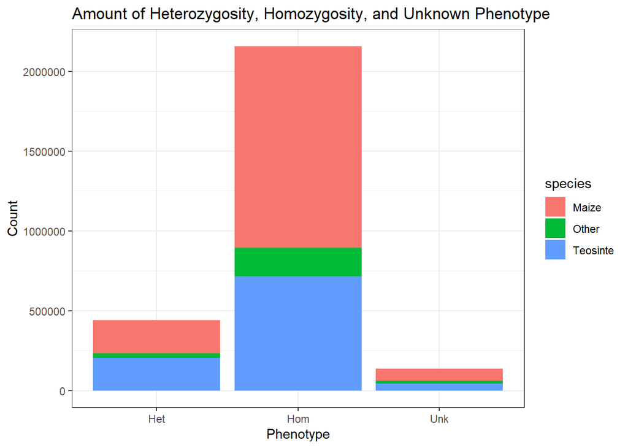

```r
fang_melt_pheno <- mutate(fang_melt_pheno, species = ifelse(Group %in% c("ZMMIL", "ZMMLR", "ZMMMR"), "Maize", ifelse(Group %in% c("ZMPBA", "ZMPIL", "ZMPJA"), "Teosinte", "Other")))

pheno2 <- ggplot(data = fang_melt_pheno) + geom_bar(mapping = aes(x=pheno, fill=species))
pheno2 + labs(title = "Amount of Heterozygosity, Homozygosity, and Unknown Phenotype", x = "Phenotype", y= "Count") + theme_bw()
```

## Other Visualization

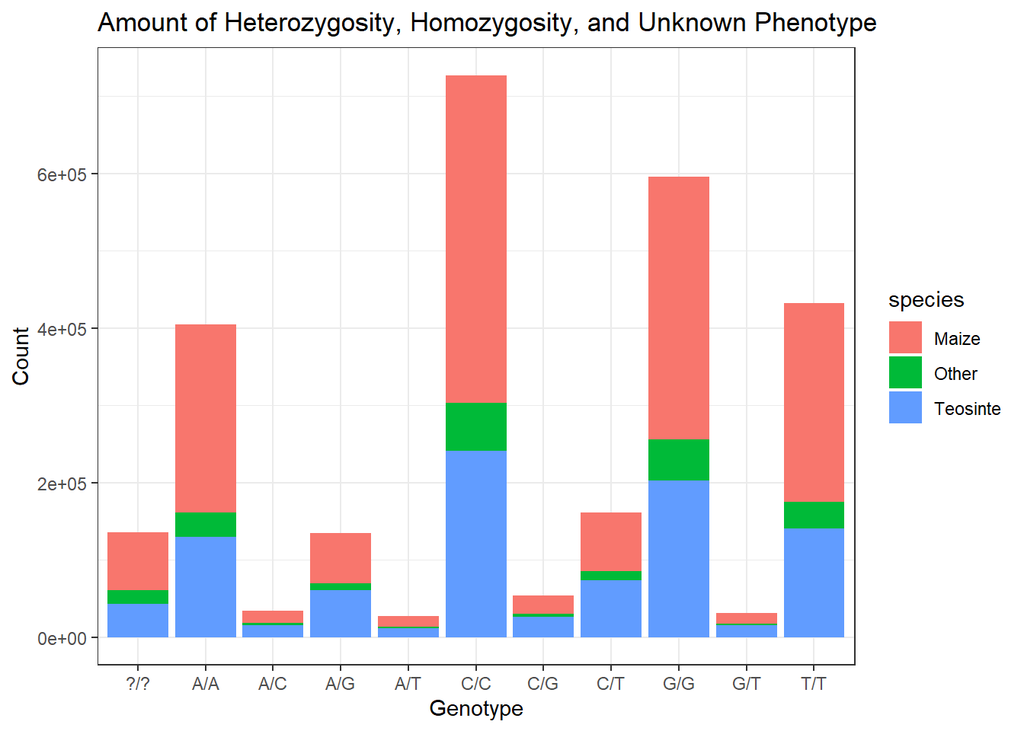

```r
genotype <- ggplot(data = fang_melt_pheno) + geom_bar(mapping = aes(x=value, fill=species))
genotype + labs(title = "Amount of Heterozygosity, Homozygosity, and Unknown Phenotype", x = "Genotype", y= "Count") + theme_bw()
```